# MinneMudac 2018

11/3/2018

## Sources of Data

- Demographic data was sourced from the ACS (American Community Survey).
- Election results sourced from the Office of the Minnesota Secretary of State.

## Sample of Data

```
## # A tibble: 6 x 7
##   Female Under5 Asian TenK_14999 Elec_Type_Gen ruff_turnout   dem
##    <dbl>  <dbl> <dbl>      <dbl>         <dbl>        <dbl> <dbl>
## 1  0.502  0.064 0.027     0.086              1        0.672 0.487
## 2  0.506  0.066 0.045     0.065              1        0.732 0.435
## 3  0.512  0.06  0.07      0.053              1        0.754 0.418
## 4  0.511  0.067 0.122     0.078              1        0.691 0.549
## 5  0.496  0.064 0.027     0.07               1        0.722 0.327
## 6  0.492  0.053 0.008     0.0970             1        0.701 0.490
```

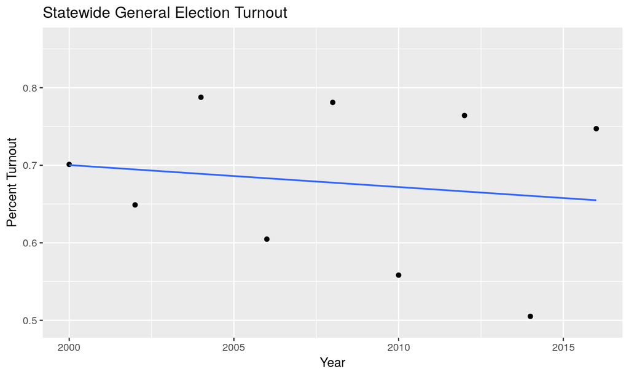

## Turnout by District from 2008-2016

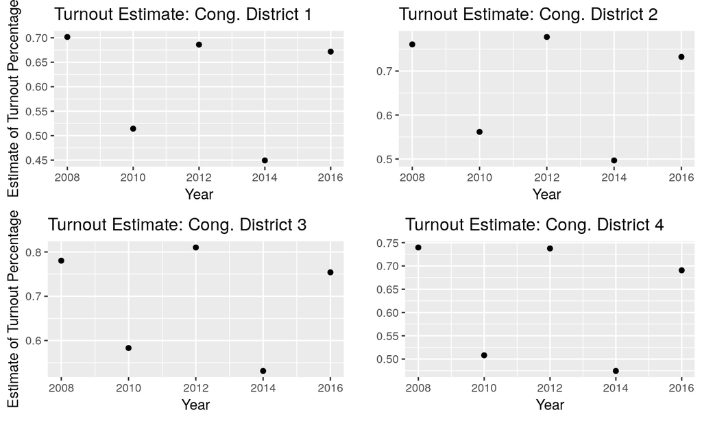

## Turnout by District from 2008-2016

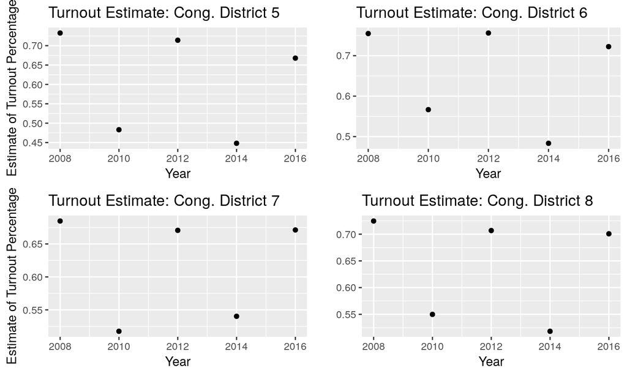

## Regsubsets: Visualization

```
## Reordering variables and trying again:
```

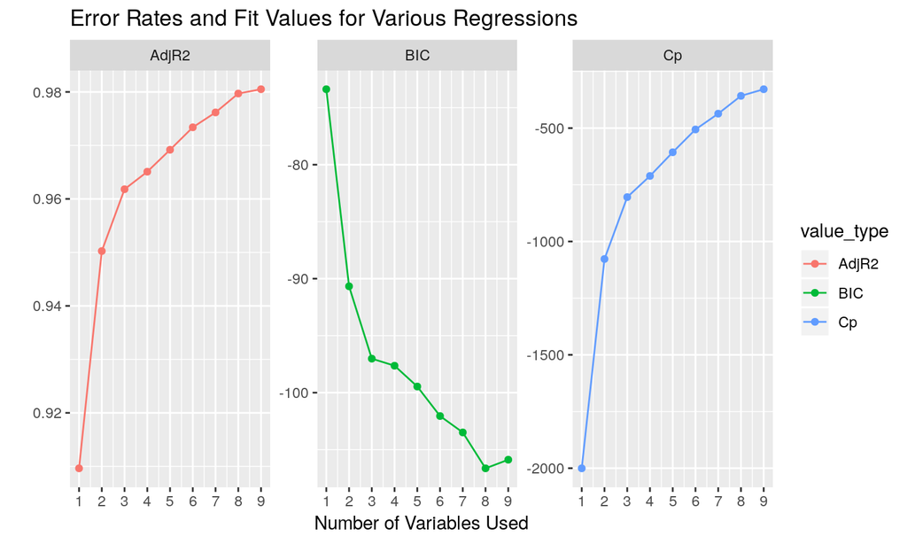

## Regsubsets: BIC Plot

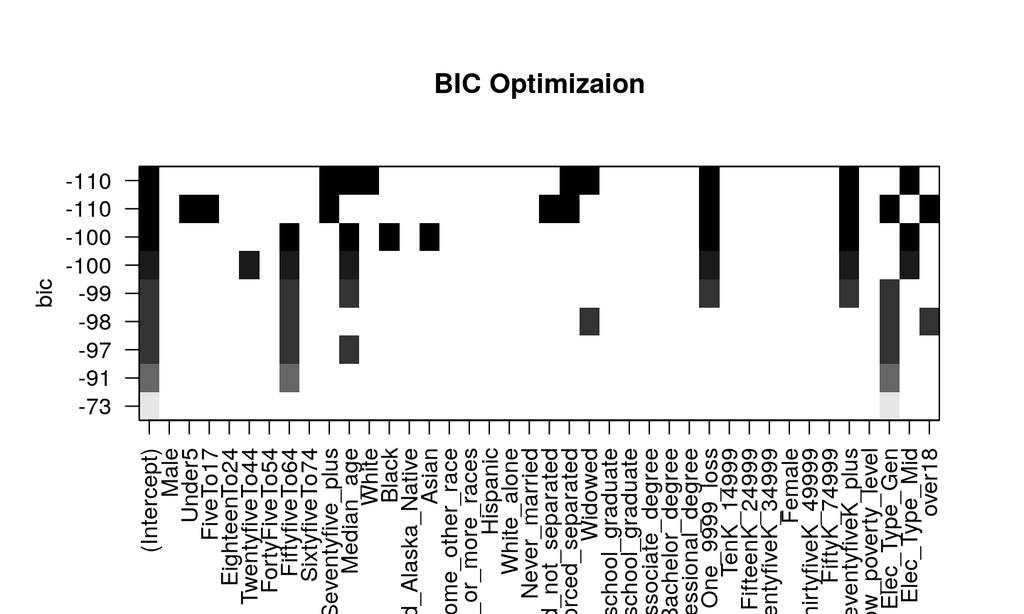

## Regression Analysis

```r
newFit = glm(ruff_turnout~FortyFiveTo54 + Divorced_separated +
             Elec_Type_Gen + over18,
             data = trainingDataMinusDR)
```

- Our model can be depicted as

\[Y = 0.7 + 1.71X_1 + 1.07X_2 + 0.22X_3 - 0.74X_4\]

Where:

- \(Y\) = Voter turnout
- \(X_1\) = Percentage of district population within the ages of forty-five to fifty-four
- \(X_2\) = Percentage of district population that are divorced and/or separated
- \(X_3\) = \(1\) if election is general, \(0\) if midterm
- \(X_4\) = Percentage of distrcit population over the age of 18

## Regression: Predictions - Test Dataset

```
## # A tibble: 6 x 5
##   FortyFiveTo54 Divorced_separated Elec_Type_Gen over18 ruff_turnout
##           <dbl>              <dbl>         <dbl>  <dbl>        <dbl>
## 1         0.117              0.123             1  0.797        0.668
## 2         0.12               0.111             1  0.764        0.671
## 3         0.168              0.106             1  0.749        0.810
## 4         0.13               0.124             1  0.791        0.714
## 5         0.166              0.102             0  0.747        0.583
## 6         0.155              0.093             0  0.728        0.567
```

## Regression: Predictions - Results

What type of results are we looking for?

- Prediction accuracy
- Do our predicted values rise and fall in tandem with actual turnout data?
- Is there consistent under/over-estimation?

## Regression: Predictions - Results

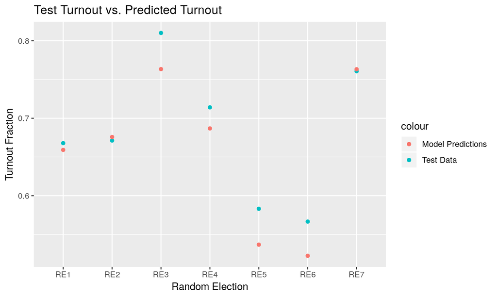

## Regression: Prediction - Insights

- Mean squared error of \(.102\%\)
- The modeled predictions dip and spike according to the rates of the test data
- The model tends to underestimate
- Less accurate predictions seem to occur when the actual turnout is significantly higher or lower than the median turnout

## Regression: Industry

- We also collected data from 2008-2014 concerning the rates of workers in different industries
- Only spans districts 3, 4, and 5

## Regression: Industry - R

Results of Regression:

```
##                                           Estimate  Std. Error    t value
## (Intercept)                             0.59197217 0.052674422  11.238323
## Elec_Type_Mid                          -0.22362414 0.011650111 -19.195022
## `finance/insurance`                     0.03350837 0.004721404   7.097120
## `professional/science/wasteManagement` -0.01220291 0.004093521  -2.981029
##                                            Pr(>|t|)
## (Intercept)                            3.528051e-06
## Elec_Type_Mid                          5.624962e-08
## `finance/insurance`                    1.022835e-04
## `professional/science/wasteManagement` 1.757279e-02
```

## Regression: Industry - Insights

Our model demonstrates negative correlation in regard to voter turnout when it comes to

- If the election is a midterm
- If the district has a higher percentage of individuals working in professional and scientific services

And positive correlation when

- The district has a higher percentage of individuals working in finance and insurance industries

Low estimates occur due to the way in which percentages were recorded in the dataset

## Black Boxes

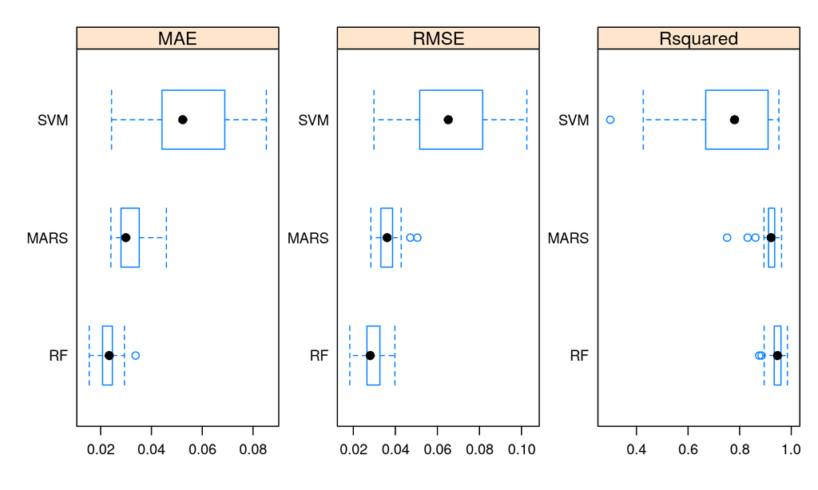

## Ensemble

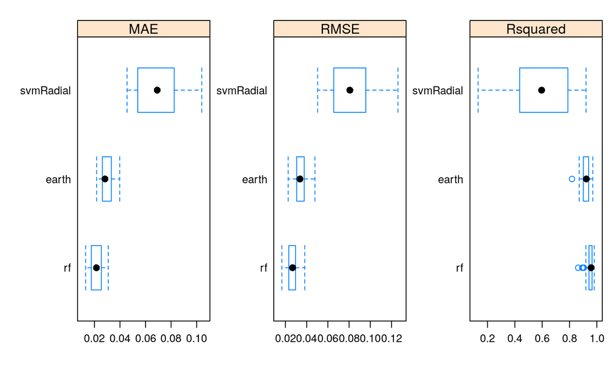

## Ensemble Results

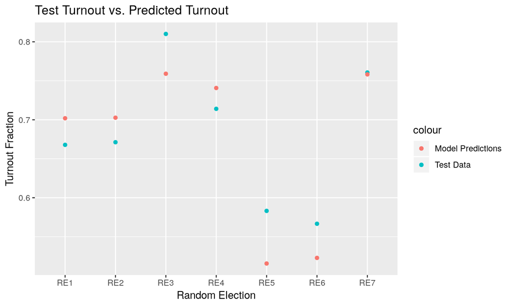

## Potential Future Models (Quantile Regression Neural Network)

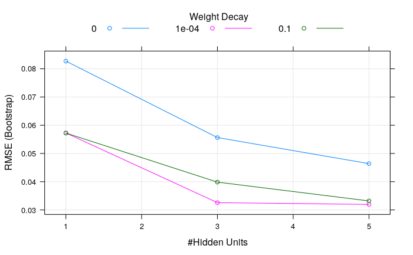

## QRNN Results

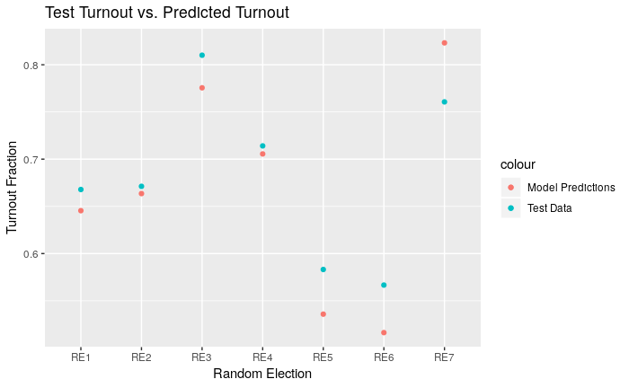